# SAVEMORE analysis

Lina Kramer

1.03.2025

### 1. Data overview

- Exposure: anakinra vs. placebo.
- Survival outcome: 28-day and 90-day survival.
- Mediator: IL6 on days 1, 4 and 7.

### 2. Descriptives

#### 2.1. Table 1

```
##                    Stratified by randomized_group
##                     Placebo       Anakinra
##   n                   187           401
##   death_d28 = 1 (%)    13 ( 7.0)     13 ( 3.2)
##   death_d90 = 1 (%)    19 (10.2)     22 ( 5.5)
##   il6_1 (mean (SD))  1.26 (0.57)   1.20 (0.54)
##   il6_4 (mean (SD))  1.05 (0.59)   0.91 (0.55)
##   il6_7 (mean (SD))  0.99 (0.63)   0.80 (0.57)
##   sex = male (%)      106 (56.7)    235 (58.6)
##   age (mean (SD))   61.53 (11.33) 62.09 (12.43)
##   bmi (mean (SD))   29.73 (5.49)  29.40 (5.53)
##   sofa (mean (SD))   2.46 (1.15)   2.38 (1.11)
```

#### 2.2. Missingness

Of 593 patients, 5 have no IL6 biomarker measures. They are not included in any of the analyses.

For the 588 subjects who do have IL6 measures, this is the pattern of missingness:

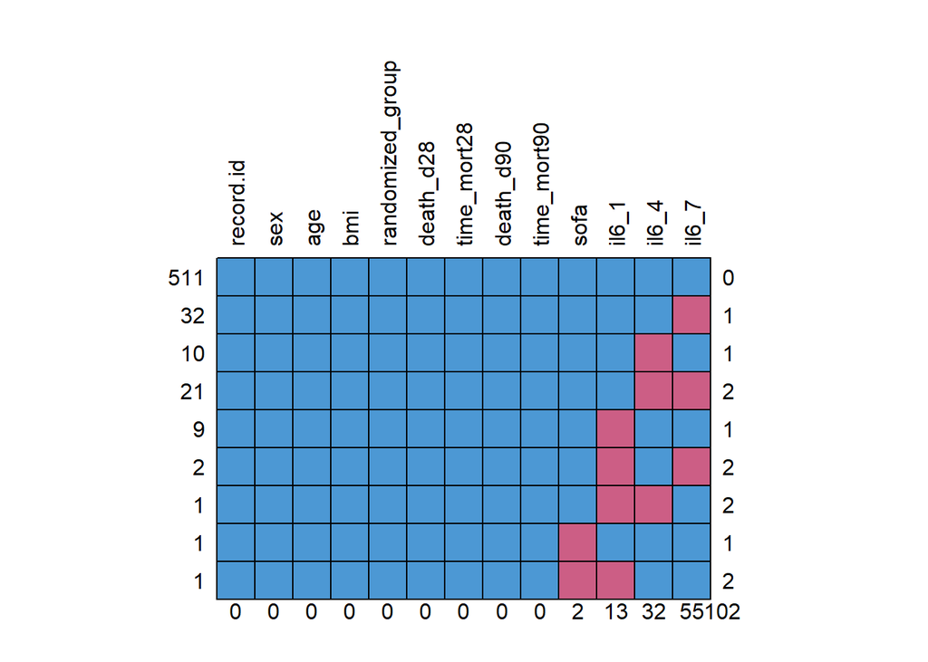

```r
missing_savemore <- mice::md.pattern(savemore_wide, rotate.names = TRUE, plot = TRUE)
```

#### 2.3. 28-day survival

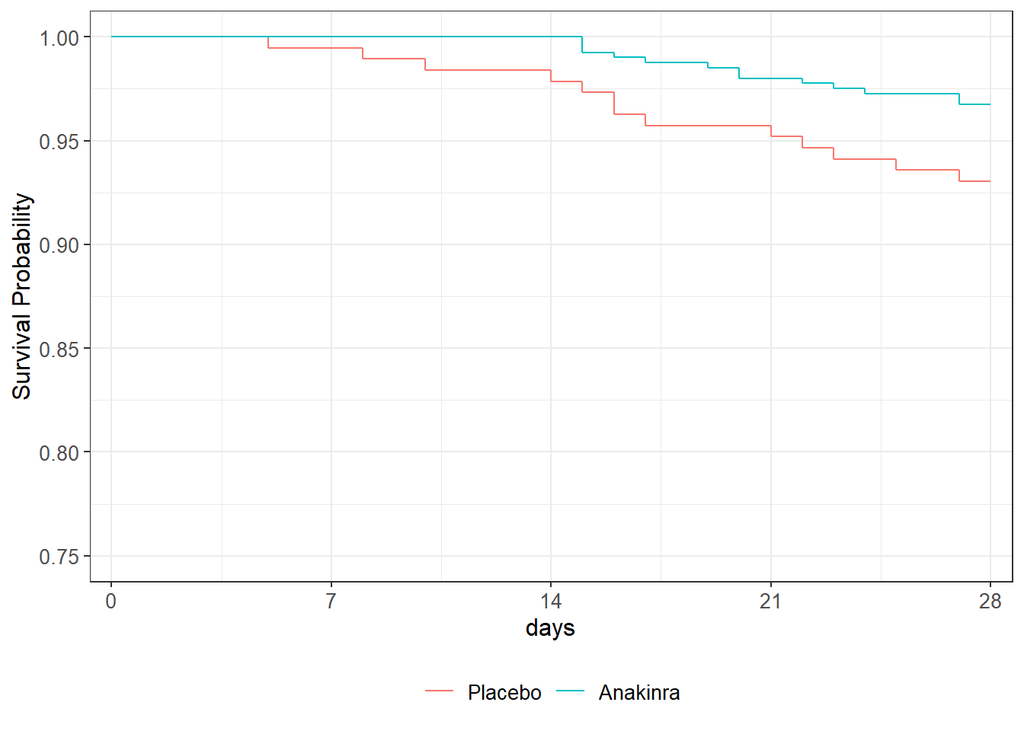

#### 2.4. 90-day survival

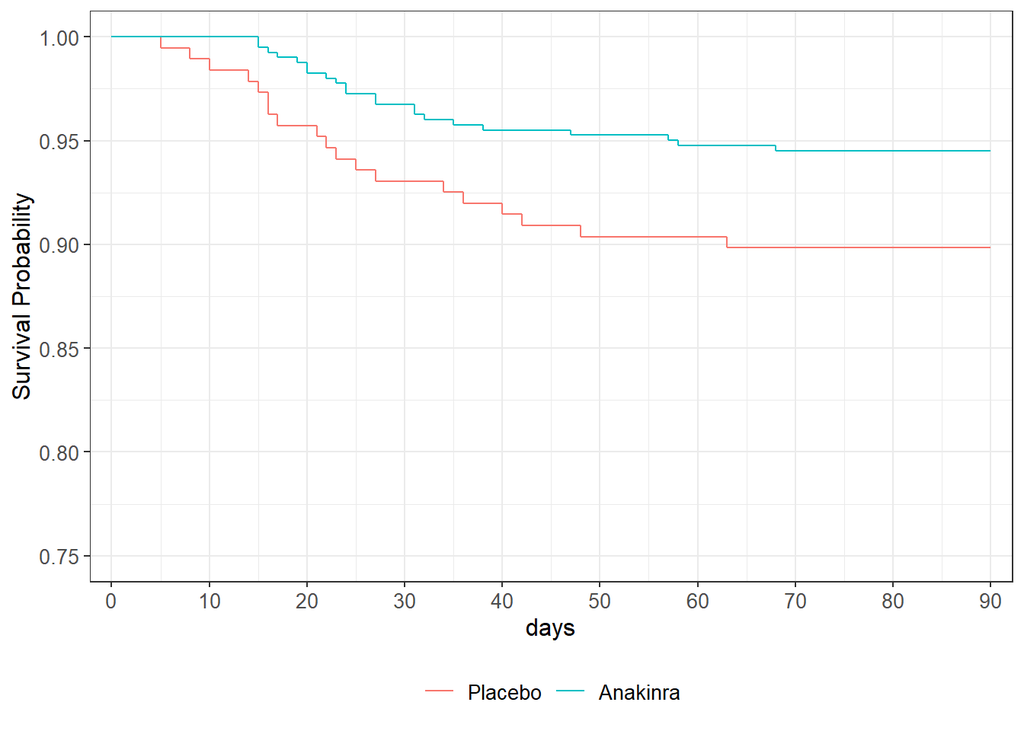

```r
class(savemore_surv$death_d90) <- "integer"

survfit2(Surv(time_mort90, death_d90) ~ randomized_group, data = savemore_surv) %>%
  ggsurvfit() +
  scale_ggsurvfit(x_scales= list(breaks = c(0, 10, 20, 30, 40, 50, 60, 70, 80, 90)))+
  ylim(c(.75, 1))+
  xlab("days")
```

#### 2.5. IL-6 over time

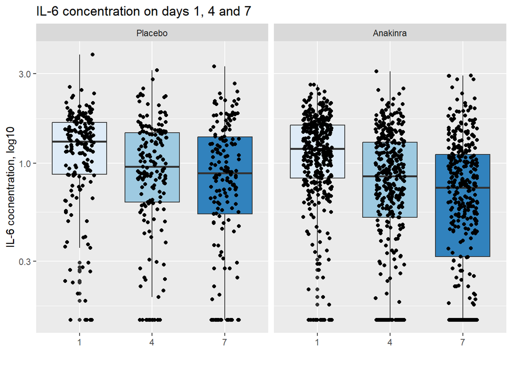

### 3. Models

#### 3.1. Linear-mixed model for IL-6 over time

```r
# fit linear mixed mdoel
lmefit.savemore <-lme(conc_log10~ day:randomized_group +day,
                   random = ~ day| record.id, data = savemore_long,
                   control = lmeControl(opt = "optim"),
                   na.action = na.omit)
summary(lmefit.savemore)
```

```
## Linear mixed-effects model fit by REML
##   Data: savemore_long
##        AIC      BIC    logLik
##   2663.727 2701.633 -1324.863
##
## Random effects:
##  Formula: ~day | record.id
##  Structure: General positive-definite, Log-Cholesky parametrization
##             StdDev     Corr
## (Intercept) 0.34478060 (Intr)
## day         0.05371349 -0.28
## Residual    0.42544483
##
## Fixed effects:  conc_log10 ~ day:randomized_group + day
##                                   Value   Std.Error   DF  t-value p-value
## (Intercept)                   1.2484091 0.024396881 1074 51.17085   0e+00
## day                          -0.0412061 0.007195113 1074 -5.72695   0e+00
## day:randomized_groupAnakinra -0.0269798 0.007669486 1074 -3.51780   5e-04
##  Correlation:
##                              (Intr) day
## day                          -0.467
## day:randomized_groupAnakinra  0.004 -0.736
##
## Standardized Within-Group Residuals:
##         Min          Q1         Med          Q3         Max
## -2.54974446 -0.58093507 -0.06755401  0.53782487  4.71086242
##
## Number of Observations: 1664
## Number of Groups: 588
```

```
## Approximate 95% confidence intervals
##
##  Fixed effects:
##                                    lower        est.       upper
## (Intercept)                   1.20053819  1.24840915  1.29628010
## day                          -0.05532416 -0.04120608 -0.02708801
## day:randomized_groupAnakinra -0.04202863 -0.02697975 -0.01193088
```

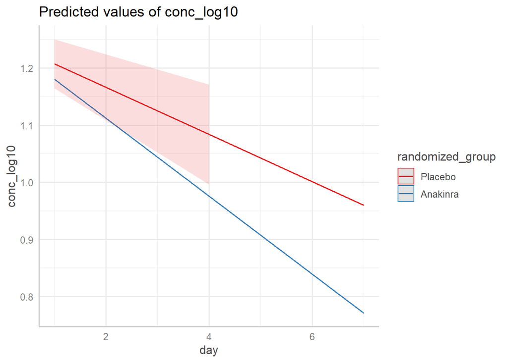

```r
library(sjPlot)
library(sjmisc)
theme_set(theme_sjplot())

plot_model(lmefit.savemore, type = "int", terms = c("randomized_group", "day"))
```

```r
# save the interaction estimate
a_res <- get_int(lmefit.savemore, "randomized_groupAnakinra")

saveRDS(a_res, "SAVEMORE_beta_est.rds")
```

#### 3.2. Cox proportional hazards models

For 28-day and 90-day survival.

##### 3.2.1. 28-day survival

```r
# Fit cox proportional hazard model
coxfit.savemore28 <- coxph(Surv(time_mort28, death_d28) ~ randomized_group, data = savemore_surv, x = TRUE)

summary(coxfit.savemore28)
```

```
## Call:
## coxph(formula = Surv(time_mort28, death_d28) ~ randomized_group,
##     data = savemore_surv, x = TRUE)
##
##   n= 588, number of events= 26
##
##                             coef exp(coef) se(coef)     z Pr(>|z|)
## randomized_groupAnakinra -0.7883    0.4546   0.3922 -2.01   0.0445 *
## ---
## Signif. codes:  0 '***' 0.001 '**' 0.01 '*' 0.05 '.' 0.1 ' ' 1
##
##                          exp(coef) exp(-coef) lower .95 upper .95
## randomized_groupAnakinra    0.4546        2.2    0.2108    0.9807
##
## Concordance= 0.595  (se = 0.049 )
## Likelihood ratio test= 3.94  on 1 df,   p=0.05
## Wald test            = 4.04  on 1 df,   p=0.04
## Score (logrank) test = 4.25  on 1 df,   p=0.04
```

```r
confint(coxfit.savemore28) %>% exp() %>% round(3)
```

```
##                          2.5 % 97.5 %
## randomized_groupAnakinra 0.211  0.981
```

##### 3.2.2. 90-day survival

```r
# Fit cox proportional hazard model
coxfit.savemore90 <- coxph(Surv(time_mort90, death_d90) ~ randomized_group, data = savemore_surv, x = TRUE)

summary(coxfit.savemore90)
```

```
## Call:
## coxph(formula = Surv(time_mort90, death_d90) ~ randomized_group,
##     data = savemore_surv, x = TRUE)
##
##   n= 588, number of events= 41
##
##                             coef exp(coef) se(coef)      z Pr(>|z|)
## randomized_groupAnakinra -0.6491    0.5225   0.3132 -2.073   0.0382 *
## ---
## Signif. codes:  0 '***' 0.001 '**' 0.01 '*' 0.05 '.' 0.1 ' ' 1
##
##                          exp(coef) exp(-coef) lower .95 upper .95
## randomized_groupAnakinra    0.5225      1.914    0.2828    0.9654
##
## Concordance= 0.577  (se = 0.039 )
## Likelihood ratio test= 4.16  on 1 df,   p=0.04
## Wald test            = 4.3  on 1 df,   p=0.04
## Score (logrank) test = 4.45  on 1 df,   p=0.03
```

```r
confint(coxfit.savemore90) %>% exp() %>% round(3)
```

```
##                          2.5 % 97.5 %
## randomized_groupAnakinra 0.283  0.965
```

#### 3.3. Joint models

Using 28- and 90-day survival as endpoints.

##### 3.3.1. 28-day endpoint

```r
set.seed(15)
# Fit joint model for 28 day survival
jointfit.savemore_28 <- JMbayes2::jm(coxfit.savemore28, lmefit.savemore, time_var = "day",  n_chains = 2, n_iter = 50000L, n_burnin = 5000L, n_thin = 5)

# save results
saveRDS(jointfit.savemore_28, "jointfit.savemore_28.rds")

# Fit joint model for 90 day survival
jointfit.savemore_90 <- JMbayes2::jm(coxfit.savemore90, lmefit.savemore, time_var = "day",  n_chains = 2, n_iter = 50000L, n_burnin = 5000L, n_thin = 5)

saveRDS(jointfit.savemore_90, "jointfit.savemore_90.rds")
```

```
##
## Call:
## JMbayes2::jm(Surv_object = coxfit.savemore28, Mixed_objects = lmefit.savemore,
##     time_var = "day", n_chains = 2, n_iter = 50000L, n_burnin = 5000L,
##     n_thin = 5)
##
## Data Descriptives:
## Number of Groups: 592        Number of events: 26 (4.4%)
## Number of Observations:
##   conc_log10: 1661
##
##                  DIC     WAIC       LPML
## marginal    2907.000 2971.415  -1550.877
## conditional 1460.744 2731.342 -21749.354
##
## Random-effects covariance matrix:
##
##        StdDev   Corr
## (Intr) 0.3143 (Intr)
## day    0.0415 0.0869
##
## Survival Outcome:
##                            Mean  StDev    2.5%  97.5%      P   Rhat
## randomized_groupAnakinra 0.2423 0.7734 -1.2396 1.8143 0.7589 1.0001
## value(conc_log10)        3.0819 0.9965  1.4228 5.3825 0.0000 1.0314
##
## Longitudinal Outcome: conc_log10 (family = gaussian, link = identity)
##                Mean  StDev    2.5%   97.5%      P   Rhat
## (Intercept)  1.1850 0.0212  1.1427  1.2265 0.0000 1.0038
## day         -0.0409 0.0077 -0.0560 -0.0258 0.0000 1.0017
## d:_A        -0.0260 0.0085 -0.0431 -0.0094 0.0016 1.0001
## sigma        0.4344 0.0109  0.4133  0.4563 0.0000 1.0011
##
## MCMC summary:
## chains: 2
## iterations per chain: 50000
## burn-in per chain: 5000
## thinning: 5
## time: 12.1 min
```

##### 3.3.2. 90-day endpoint

```
##
## Call:
## JMbayes2::jm(Surv_object = coxfit.savemore90, Mixed_objects = lmefit.savemore,
##     time_var = "day", n_chains = 2, n_iter = 50000L, n_burnin = 5000L,
##     n_thin = 5)
##
## Data Descriptives:
## Number of Groups: 592        Number of events: 41 (6.9%)
## Number of Observations:
##   conc_log10: 1661
##
##                     DIC         WAIC          LPML
## marginal       3311.347 6.021164e+03 -4.206220e+03
## conditional 3447233.293 6.678743e+16 -6.634874e+10
##
## Random-effects covariance matrix:
##
##        StdDev   Corr
## (Intr) 0.3224 (Intr)
## day    0.0667 -0.1341
##
## Survival Outcome:
##                             Mean  StDev    2.5%  97.5%      P   Rhat
## randomized_groupAnakinra -0.1051 0.9359 -2.1706 1.6944 0.9277 1.0621
## value(conc_log10)         1.9649 0.5242  0.9024 2.7771 0.0000 1.3804
##
## Longitudinal Outcome: conc_log10 (family = gaussian, link = identity)
##                Mean  StDev    2.5%   97.5%      P   Rhat
## (Intercept)  1.1629 0.0295  1.1044  1.2164 0.0000 1.3484
## day         -0.0308 0.0136 -0.0535 -0.0030 0.0254 1.4917
## d:_A        -0.0290 0.0105 -0.0506 -0.0094 0.0030 1.0976
## sigma        0.4282 0.0113  0.4063  0.4508 0.0000 1.0032
##
## MCMC summary:
## chains: 2
## iterations per chain: 50000
## burn-in per chain: 5000
## thinning: 5
## time: 5 min
```

### 4. Results

#### 4.1. Indirect, direct, and total effects

Of anakinra through IL6 on the hazard of death.

```r
res28 <- get_effects(jointfit.savemore_28, coxfit.savemore28,
                     "randomized_groupAnakinra") %>% cbind(endpoint =c("28-day endpoint"))

res28
```

```
##           effect         est   CI_lower    CI_upper        endpoint
## 1         direct  0.24229995 -1.2395534  1.81427247 28-day endpoint
## 2       indirect -0.08003438 -0.1567002 -0.02451719 28-day endpoint
## 3 total (Cox-PH) -0.78825892 -1.5570289 -0.01948896 28-day endpoint
## 4     total (JM)  0.16226557 -1.3027106  1.70492160 28-day endpoint
```

```r
res90 <- get_effects(jointfit.savemore_90, coxfit.savemore90,
                     "randomized_groupAnakinra") %>% cbind(endpoint =c("90-day endpoint"))

res90
```

```
##           effect         est  CI_lower    CI_upper        endpoint
## 1         direct -0.10505573 -2.170580  1.69444173 90-day endpoint
## 2       indirect -0.05689723 -0.126946 -0.01364629 90-day endpoint
## 3 total (Cox-PH) -0.64909520 -1.262941 -0.03524972 90-day endpoint
## 4     total (JM) -0.16195296 -2.246248  1.60819108 90-day endpoint
```

```r
res <- rbind(res28, res90)
saveRDS(res, "savemore_res.rds")
```

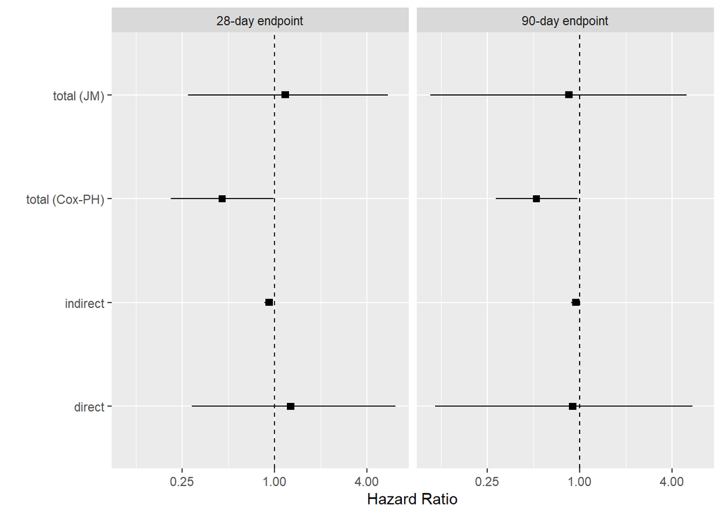

```r
res %>%
  ggplot(aes(y = effect))+
  theme_grey()+
  geom_point(aes(x=exp(est)), shape=15, size=2) +
  geom_linerange(aes(xmin=exp(CI_lower), xmax=exp(CI_upper))) +
   geom_vline(xintercept = 1, linetype="dashed") +
  labs(x="Hazard Ratio", y= "")+
  scale_x_continuous(trans = "log2")+
  facet_grid(~endpoint)
```

#### 4.2. Association parameter

```r
# save association estimates

alpha_28 <- get_alpha(jointfit.savemore_28, "28-day endpoint")
alpha_90 <- get_alpha(jointfit.savemore_90, "90-day endpoint")

alpha_est <- rbind(alpha_28, alpha_90)

saveRDS(alpha_est, "SAVEMORE_alpha_est.rds")
```

#### 4.4. Conclusions

- From lme and JM we can conclude that there is an effect of anakinra over time on IL-6.
- From joint model we conclude 1) that there is no direct effect of anakinra on survival when controlling for IL-6, 2) there is an association between IL-6 and survival, and (3) some of the effect of anakinra is mediated by IL-6.

### 5. Model checks

#### 5.1. Longitudinal submodel

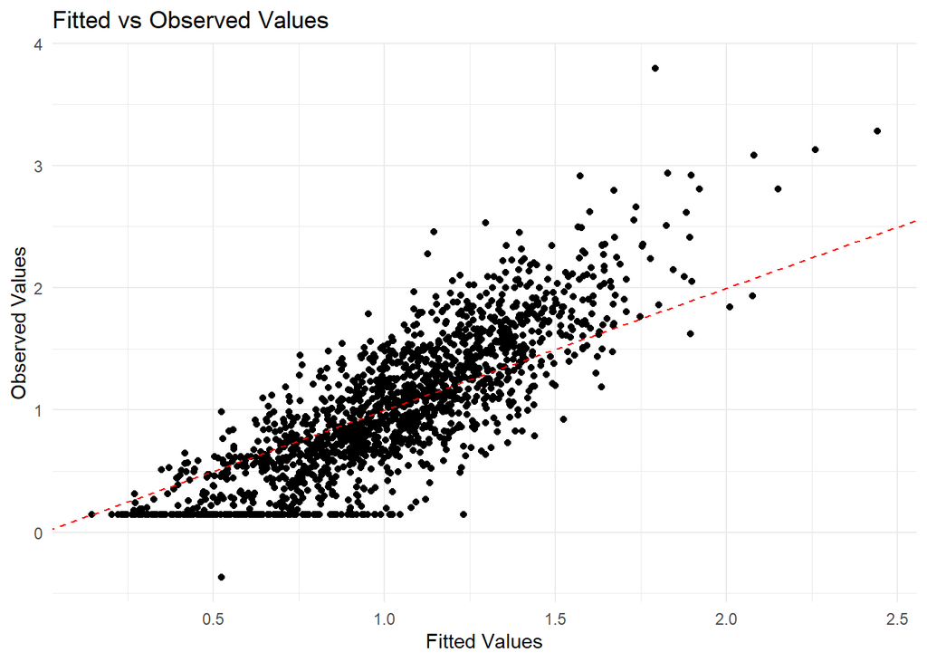

```r
# get fitted values
fitted_values<- fitted(lmefit.savemore)
savemore_long <- savemore_long %>% drop_na(conc_log10)

# plot observed vs fitted values
ggplot(data = savemore_long, aes(x = fitted_values, y = conc_log10)) +
  geom_point() +
  geom_abline(slope = 1, intercept = 0, linetype = "dashed", color = "red") +  # Line of perfect fit
  labs(x = "Fitted Values", y = "Observed Values") +
  ggtitle("Fitted vs Observed Values") +
  theme_minimal()
```

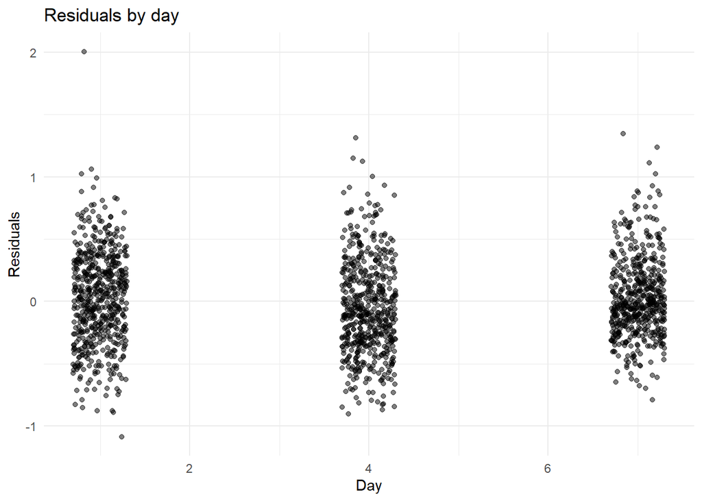

```r
# get residuals
residuals_values <- resid(lmefit.savemore)


# plot residuals vs time
ggplot(savemore_long, aes(x = day, y = residuals_values)) +
  geom_jitter(width = 0.3, alpha = 0.5) +
  labs(x = "Day", y = "Residuals") +
  ggtitle("Residuals by day") +
  theme_minimal()
```

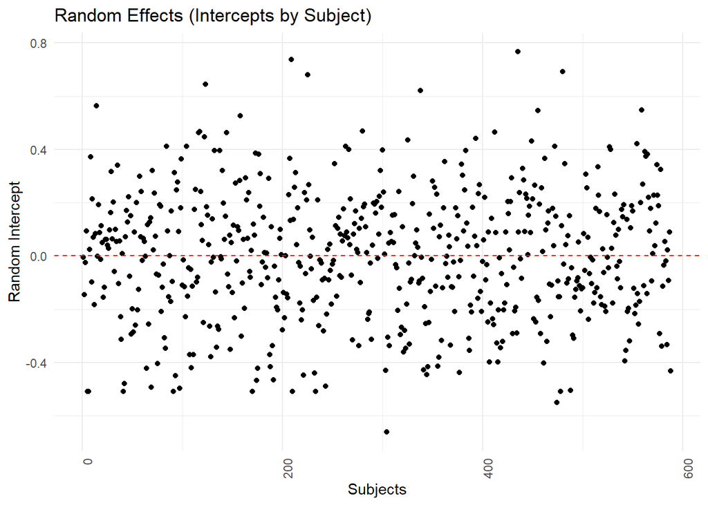

```r
# get random effects
random_effects <- ranef(lmefit.savemore)

#plot random effects
ggplot(random_effects, aes(x = c(1:nrow(savemore_surv)), y = `(Intercept)`)) +
  geom_point() +
  geom_hline(yintercept = 0, linetype = "dashed", color = "red") +
  labs(x = "Subjects", y = "Random Intercept") +
  ggtitle("Random Effects (Intercepts by Subject)") +
  theme_minimal() +
  theme(axis.text.x = element_text(angle = 90, hjust = 1))
```

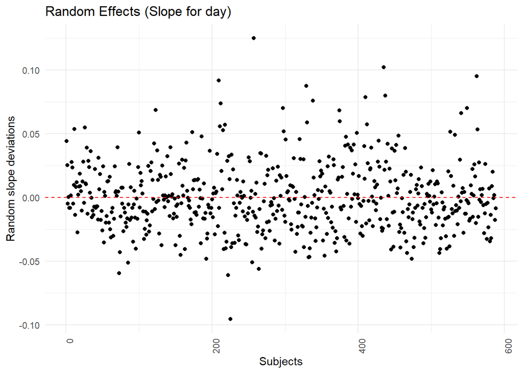

```r
#plot random effects
ggplot(random_effects, aes(x = c(1:nrow(savemore_surv)), y = `day`)) +
  geom_point() +
  geom_hline(yintercept = 0, linetype = "dashed", color = "red") +
  labs(x = "Subjects", y = "Random slope deviations") +
  ggtitle("Random Effects (Slope for day)") +
  theme_minimal() +
  theme(axis.text.x = element_text(angle = 90, hjust = 1))
```

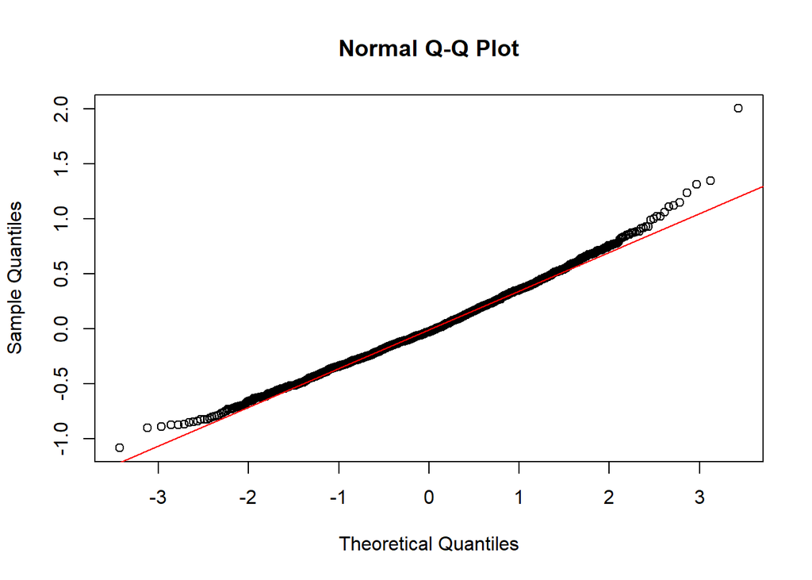

```r
# qq plot for residuals
qqnorm(resid(lmefit.savemore))

qqline(resid(lmefit.savemore), col = "red")
```

#### 5.2 Survival submodel

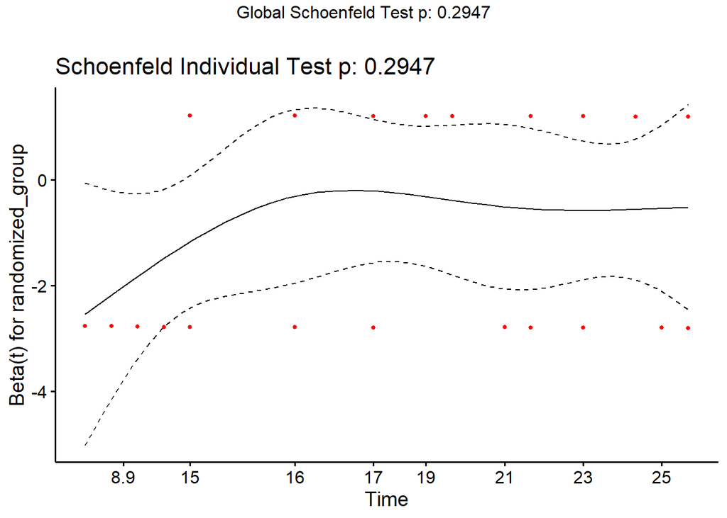

```r
test.ph <- cox.zph(coxfit.savemore28)
survminer::ggcoxzph(test.ph)
```

#### 5.1. 28-day endpoint

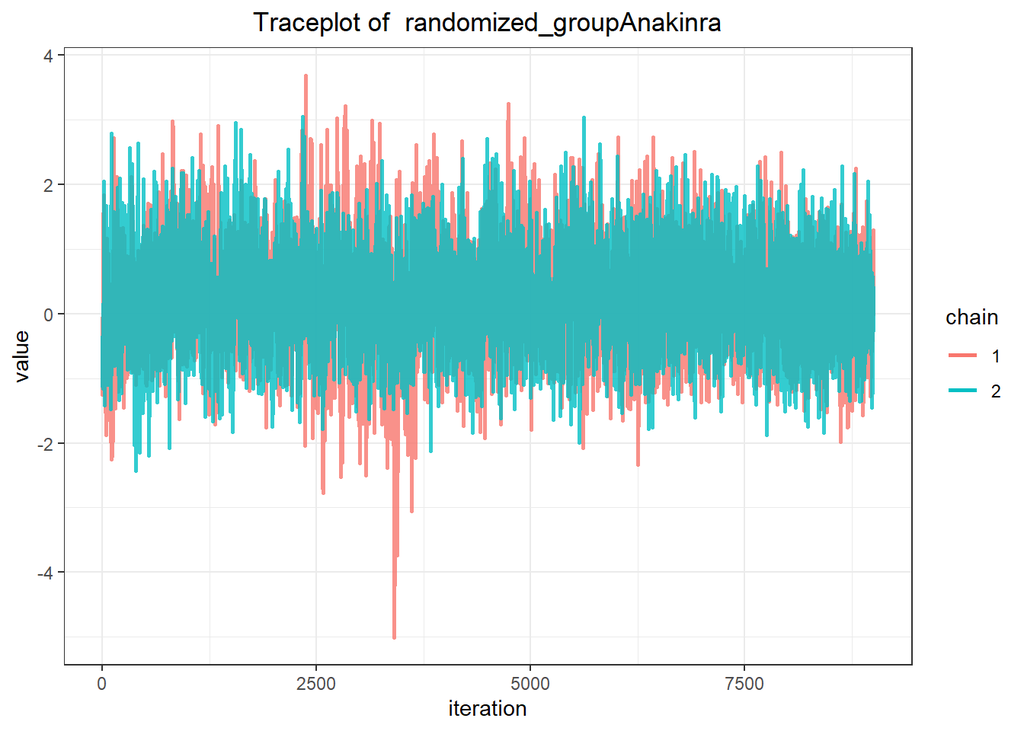

```r
ggtraceplot(jointfit.savemore_28, "gammas")
```

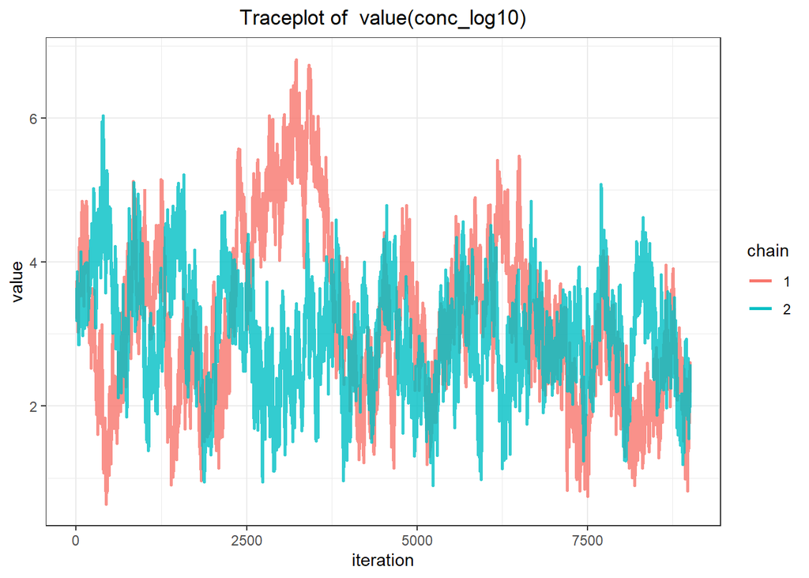

```r
ggtraceplot(jointfit.savemore_28, "alphas")
```

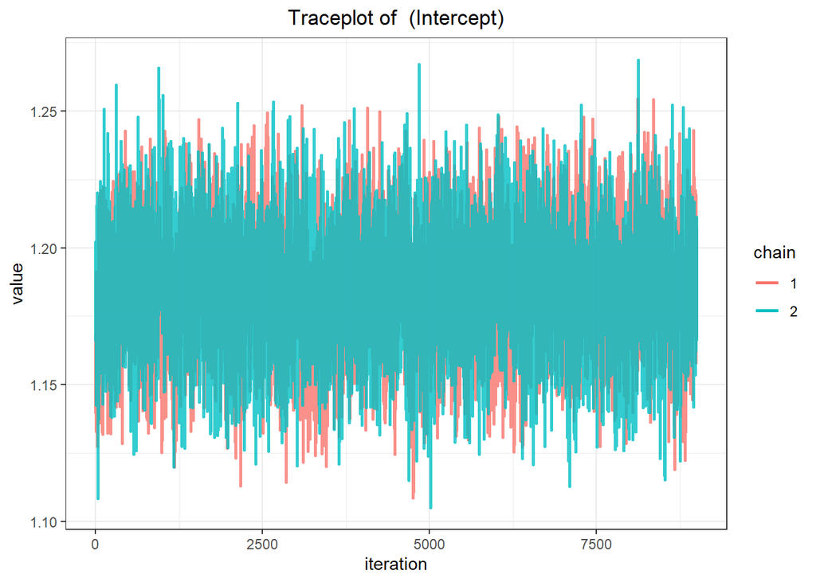

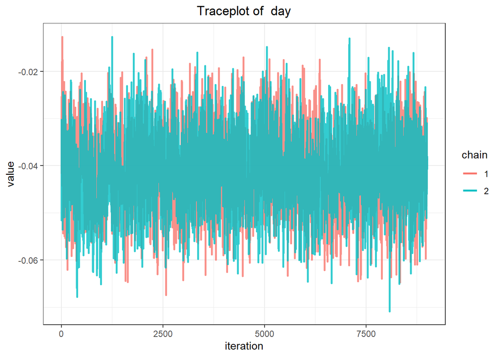

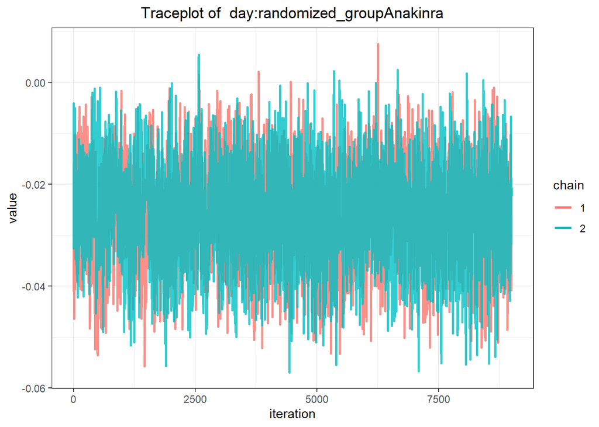

```r
ggtraceplot(jointfit.savemore_28, "betas")
```

#### 5.2. 90-day endpoint

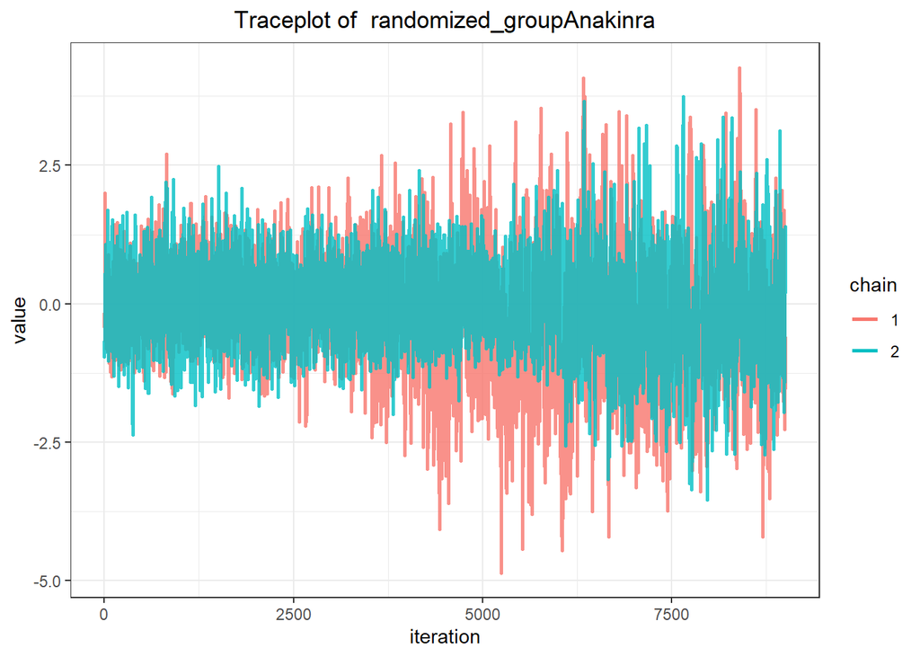

```r
ggtraceplot(jointfit.savemore_90, "gammas")
```

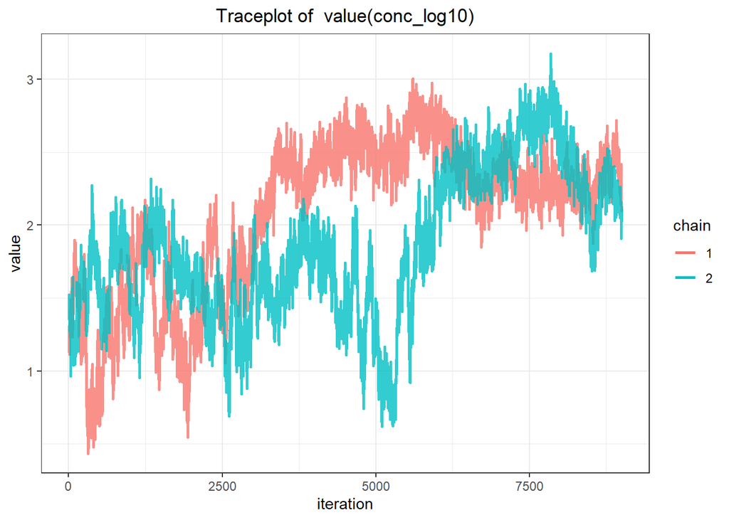

```r
ggtraceplot(jointfit.savemore_90, "alphas")
```

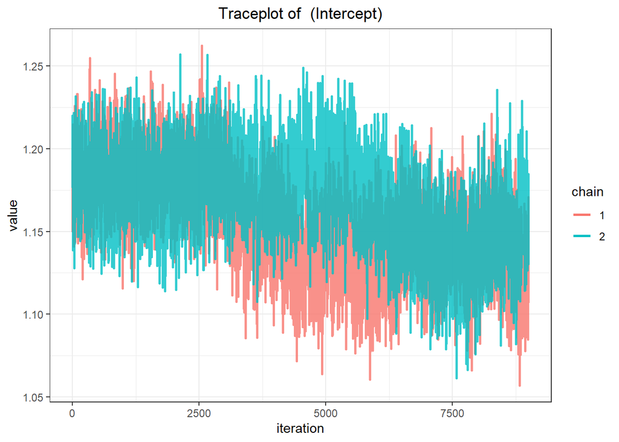

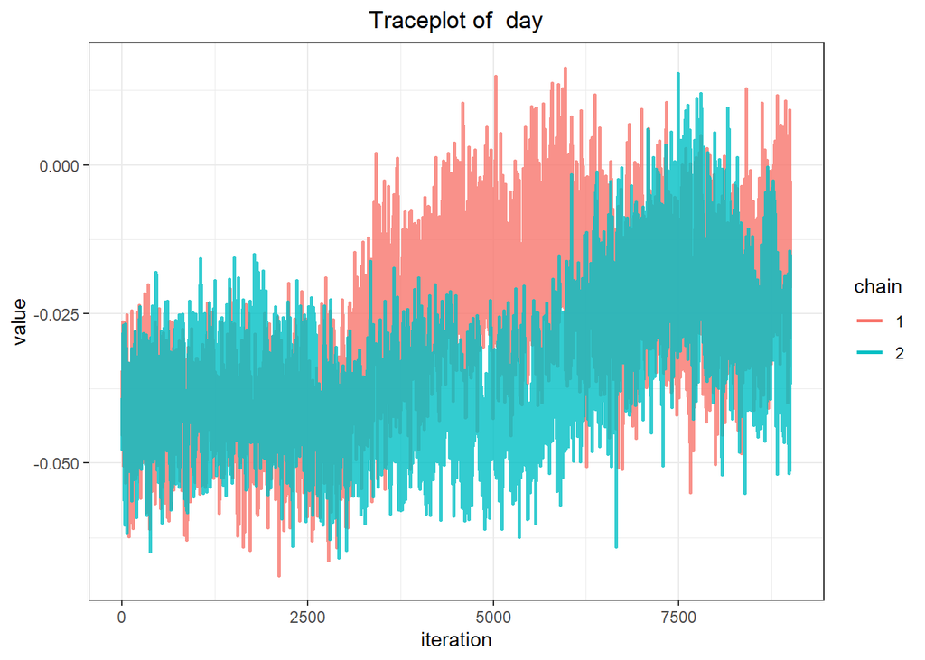

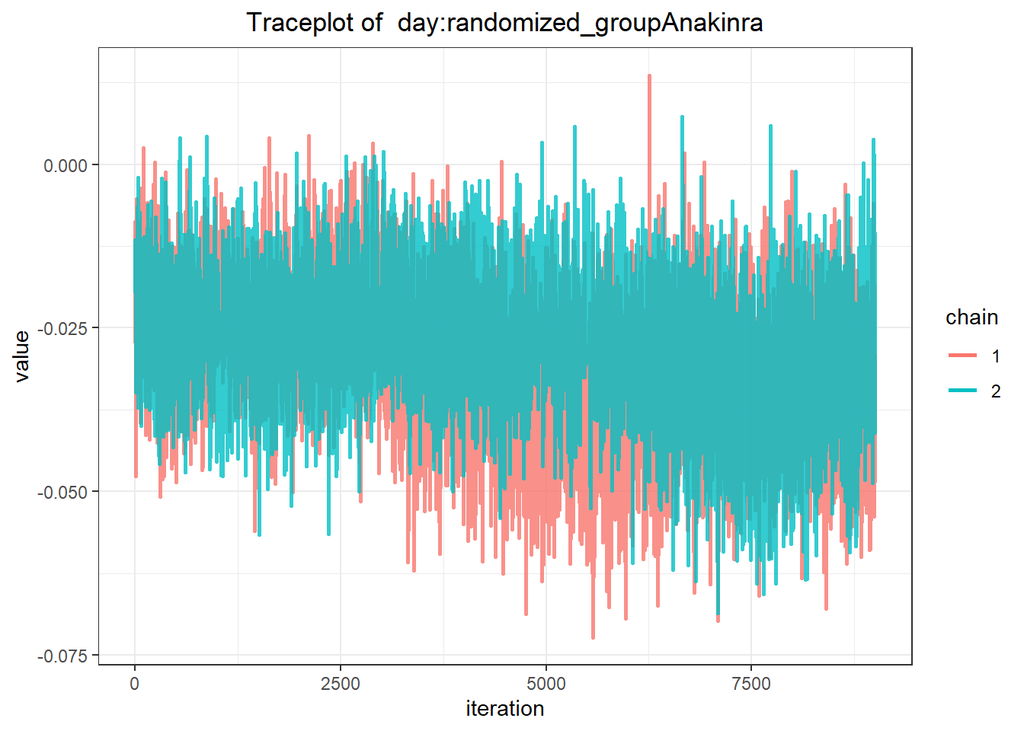

```r
ggtraceplot(jointfit.savemore_90, "betas")
```